# R Notebook

##### Model-2 Multi-class classification

###### Feature Selection:

Response Variable:

RSKMRJWK - RISK SMOKING MARIJUANA ONCE OR TWICE A WEEK

```r
info_gain_2 <- information.gain(rskmrjwk ~ ., data=df)
info_gain_2
```

|  | attr_importance |
| --- | --- |
| ymdelt | 0.0209305364 |
| CATAG7 | 0.0487747165 |
| drvindrg | 0.0158112847 |
| uadfwho | 0.0230544014 |
| irwrkstat | 0.0453539702 |
| iralcfy | 0.0577874451 |
| irmjfy | 0.0871191476 |
| irmjfm | 0.0617222752 |
| irmjage | 0.0897850403 |
| mrjflag | 0.0894155453 |

[output cut: 69 more lines]

```r
df2 <- df %>% select(c("rskmrjwk","YFLTMRJ2","FRDMEVR2","irmjfy","mrjydays","PRMJEVR2","iralcrc","alcflag","stndsmj","CATAG7",
                         "EDUSCHGRD2","irwrkstat","tobflag","stndalc","PRLMTTV2"))
```

###### Splitting of Training and Test datasets

```r
set.seed(5)
train <- sample(1:nrow(df2), nrow(df2)*0.7)
NSDUH_train_set_2 <- df2[train,]
NSDUH_test_set_2 <- df2[-train,]
```

###### Decision Tree

Ignoring the Other drug related parameters

```r
model_2 <-tree(rskmrjwk ~., NSDUH_train_set_2)
summary(model_2)
```

```
Classification tree:
tree(formula = rskmrjwk ~ ., data = NSDUH_train_set_2)
Variables actually used in tree construction:
[1] "YFLTMRJ2" "PRMJEVR2" "iralcrc"  "irmjfy"
Number of terminal nodes:  5
Residual mean deviance:  2.464 = 9471 / 3844
Misclassification error rate: 0.5443 = 2095 / 3849
```

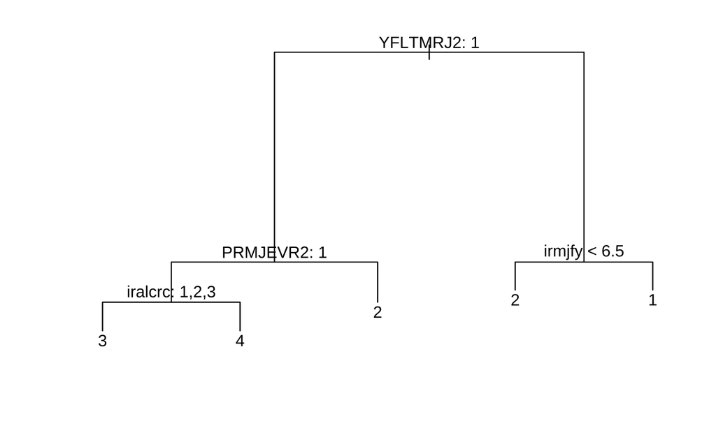

```r
plot(model_2)
text(model_2,pretty=0)
```

Accuracy of the model on Train dataset

```r
m2test_pred <- predict(model_2,NSDUH_train_set_2,type="class")
table(m2test_pred,NSDUH_train_set_2$rskmrjwk)
```

```
m2test_pred    0    1    2    3    4
          0    0    0    0    0    0
          1    0  137   77   16    4
          2    5  200  317  220   78
          3    6   49  118  125  114
          4   50  104  329  725 1175
```

```r
mean(m2test_pred==NSDUH_train_set_2$rskmrjwk)
```

```
[1] 0.4557028
```

Accuracy of the model on test dataset

```r
m2test_pred <- predict(model_2,NSDUH_test_set_2,type="class")
table(m2test_pred,NSDUH_test_set_2$rskmrjwk)
```

```
m2test_pred   0   1   2   3   4
          0   0   0   0   0   0
          1   0  61  30   9   0
          2   2  78 128  65  38
          3   4  16  50  57  35
          4  29  51 157 320 521
```

```r
mean(m2test_pred==NSDUH_test_set_2$rskmrjwk)
```

```
[1] 0.4645669
```

The model performs well for the test dataset when compared to the training data . this is because of the model unfitting to the training data

###### Bagging:

```r
bag.model2 <- randomForest(rskmrjwk ~., data = NSDUH_train_set_2, mtry =length(NSDUH_train_set_2) , importance = TRUE)
bag.model2
```

```
Call:
 randomForest(formula = rskmrjwk ~ ., data = NSDUH_train_set_2,      mtry = length(NSDUH_train_set_2), importance = TRUE)
               Type of random forest: classification
                     Number of trees: 500
No. of variables tried at each split: 14

        OOB estimate of  error rate: 58.85%
Confusion matrix:
  0   1   2   3    4 class.error
0 0   0   7   9   45   1.0000000
1 0 165 157  73   95   0.6632653
2 2 162 215 190  272   0.7443520
3 2  68 189 197  630   0.8186004
4 3  29 107 225 1007   0.2654996
```

```r
yhat.train.bag <- predict(bag.model2, newdata = NSDUH_train_set_2,type="class")
table(yhat.train.bag,NSDUH_train_set_2$rskmrjwk)
```

```
yhat.train.bag    0    1    2    3    4
             0    8    0    2    0    2
             1    0  386   30   19   12
             2    1   19  548   59   40
             3    7   16   56  493  111
             4   45   69  205  515 1206
```

```r
mean(yhat.train.bag == NSDUH_train_set_2$rskmrjwk)
```

```
[1] 0.6861522
```

```r
yhat.test.bag <- predict(bag.model2, newdata = NSDUH_test_set_2,type="class")
table(yhat.test.bag,NSDUH_test_set_2$rskmrjwk)
```

```
yhat.test.bag   0   1   2   3   4
            0   0   0   0   0   0
            1   1  70  62  20  15
            2   2  69 120  65  45
            3   3  30  59 100  87
            4  29  37 124 266 447
```

```r
mean(yhat.test.bag == NSDUH_test_set_2$rskmrjwk)
```

```
[1] 0.4463961
```

###### Cross-Validation of optimal subset of parameter for Random Forest

```r
set.seed(5)

p <- seq(1,length(NSDUH_train_set_2),by=1)
error<-c( )

for(i in 1:length(p))
{
  rf.model2 <- randomForest(rskmrjwk ~., data = NSDUH_train_set_2, mtry = i, importance = TRUE)
yhat.rf <- predict(rf.model2, newdata = NSDUH_test_set_2)
error[i] = mean(yhat.rf!= NSDUH_test_set_2$rskmrjwk)

}
```

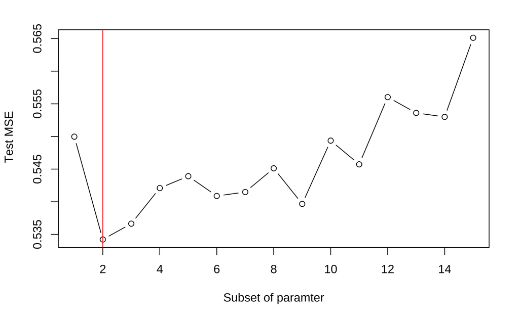

```r
plot(p,error,type="b",xlab ="Subset of paramter",ylab=" Test MSE")
index<- which.min(round(error,2)) # Index of the minimum MSE
Min_error <- error[index]
min_p <- p[index]
abline(v=min_p,col="red")
```

```r
#text(min_p,Min_error,"Least Mse")
best_subset = min_p

print(paste("Best number of subset of variable selection is : ",best_subset," has the test error rate of :",Min_error))
```

```
[1] "Best number of subset of variable selection is :  2  has the test error rate of : 0.534221683827983"
```

###### Training and Test Mse for the Random Forest model with parameter subset of 2 variables

```r
bag.model2e <- randomForest(rskmrjwk ~ ., data = NSDUH_train_set_2, mtry = 2,ntree=1000,importance = TRUE)
yhat.train.bag <- predict(bag.model2e, newdata = NSDUH_train_set_2,type="class")

table(yhat.train.bag,NSDUH_train_set_2$rskmrjwk)
```

```
yhat.train.bag    0    1    2    3    4
             0    0    0    0    0    0
             1    0  237   21    7    4
             2    6  102  453  114   49
             3    3   24   19  206   21
             4   52  127  348  759 1297
```

```r
mean(yhat.train.bag == NSDUH_train_set_2$rskmrjwk)
```

```
[1] 0.5697584
```

```r
print(paste("Train MSE of the Bagging model:",mean(yhat.train.bag ==NSDUH_train_set_2$rskmrjwk)))
```

```
[1] "Train MSE of the Bagging model: 0.569758378799688"
```

```r
bag.model2e <- randomForest(rskmrjwk ~ ., data = NSDUH_train_set_2, mtry = 2,ntree=1000,importance = TRUE)
yhat.test.bag <- predict(bag.model2e, newdata = NSDUH_test_set_2,type="class")

table(yhat.test.bag,NSDUH_test_set_2$rskmrjwk)
```

```
yhat.test.bag   0   1   2   3   4
            0   0   0   0   0   0
            1   0  60  34   9   1
            2   1  81 129  68  26
            3   2  13  23  38  23
            4  32  52 179 336 544
```

```r
mean(yhat.test.bag == NSDUH_test_set_2$rskmrjwk)
```

```
[1] 0.4669897
```

```r
print(paste("Test MSE of the RF model with p=2:",mean(yhat.test.bag ==NSDUH_test_set_2$rskmrjwk)))
```

```
[1] "Test MSE of the RF model with p=2: 0.466989703210176"
```

```r
bag.model2e <- randomForest(rskmrjwk ~ ., data = NSDUH_train_set_2, mtry = 2,ntree=1000,importance = TRUE)
bag.model2a <- randomForest(rskmrjwk ~ ., data = NSDUH_train_set_2, mtry = 15,ntree=1000,importance = TRUE)
```

```r
importance(bag.model2)
```

```
                    0          1           2           3         4 MeanDecreaseAccuracy MeanDecreaseGini
YFLTMRJ2    -8.631518  20.289824  -6.5475207 -24.0522640  81.20180             54.77671        176.41698
FRDMEVR2   -10.540850   3.161050 -13.4653833 -27.5710005 108.48946             63.05895         71.99616
irmjfy       0.000000  31.903262  -8.1856800  -4.1996081  19.59761             31.50133        136.34531
mrjydays     0.000000   1.815368   0.3428367  -3.7647859  14.09134             10.79563         24.19451
PRMJEVR2    -4.620361  10.078105 -15.5029947 -34.0108002 114.14866             65.11526         71.04164
iralcrc     -4.642463  -4.404897  -6.8654063  -4.8410804  30.20972             22.24063        117.12311
alcflag     -1.908072   5.825848  -7.5048740  -9.9320282  18.36602             16.46663         31.88752
stndsmj     -1.001002  18.387063 -18.3551052 -26.3901149  62.13087             39.50298         69.24078
CATAG7     -16.093162  -3.918688   2.7258651 -18.6693702  35.78870             32.83815         85.71705
EDUSCHGRD2  -8.110606  -5.387175  -0.4333044 -23.1032959  35.65405             30.60398        281.56347
irwrkstat   -1.001002   4.877896 -16.3972869   0.3558764  20.98262             20.31804        148.55309
tobflag     -5.104730   6.870350 -15.5030274 -17.5051679  38.22419             15.48553         57.86944
stndalc     -1.409499 -11.124571  -4.0811111 -33.0265220  56.84909             30.54974         90.17522
PRLMTTV2    -1.001002  -2.615399   2.0801131  -1.8224569  16.46187             12.77181         83.52793
```

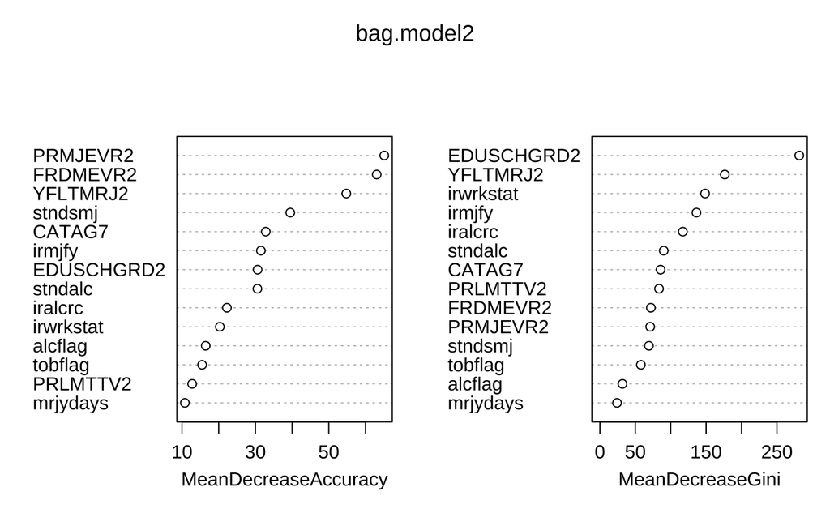

```r
varImpPlot(bag.model2)
```

###### Boosting:

```r
model2.boost1 = gbm(rskmrjwk ~ ., data = NSDUH_train_set_2,  distribution = "gaussian",
                    n.trees = 1000, shrinkage = 0.01)
model2.boost2 = gbm(rskmrjwk ~ ., data = NSDUH_train_set_2,  distribution = "gaussian",
                    n.trees = 1000,shrinkage = 0.05)
model2.boost3 = gbm(rskmrjwk ~ ., data = NSDUH_train_set_2,  distribution = "gaussian",
                    n.trees = 1000, shrinkage = 0.1)
model2.boost4 = gbm(rskmrjwk ~ ., data = NSDUH_train_set_2,  distribution = "gaussian",
                    n.trees = 1000,shrinkage = 0.2)
model2.boost5 = gbm(rskmrjwk ~ ., data = NSDUH_train_set_2,  distribution = "gaussian",
                    n.trees = 1000, shrinkage = 0.4)
model2.boost6 = gbm(rskmrjwk ~ ., data = NSDUH_train_set_2,  distribution = "gaussian",
                    n.trees = 1000, shrinkage = 0.5)
```

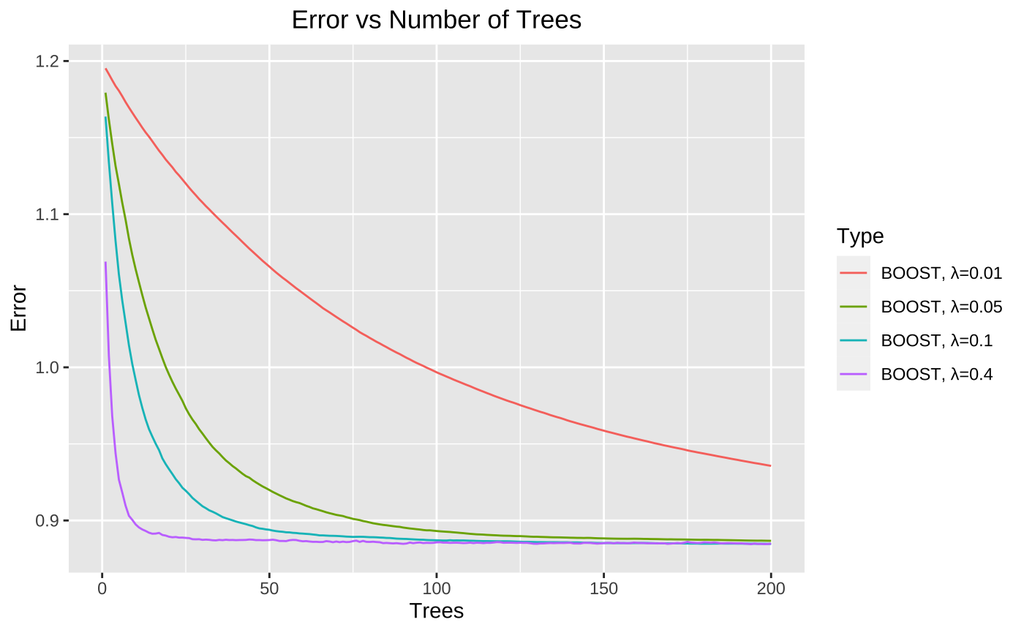

```r
model2.err <- data.frame(
  Trees=1:1000,
  Error=c(model2.boost1$train.error,model2.boost2$train.error,model2.boost3$train.error,
          model2.boost5$train.error),
  Type=rep(c("BOOST, λ=0.01","BOOST, λ=0.05", "BOOST, λ=0.1","BOOST, λ=0.4"), each=1000)
)
ggplot(data=model2.err, aes(x=Trees, y=Error)) +  geom_line(aes(color=Type)) + ggtitle("Error vs Number of Trees") +xlim(0,200)+theme(plot.title = element_text(hjust=0.5))
```

###### Training and Test error rate :

```r
model2.boost = gbm(rskmrjwk ~ ., data = NSDUH_train_set_2,  distribution = "gaussian",
                    n.trees = 1000,shrinkage = 0.4)

boost.pred_train_2 <- predict(model2.boost,NSDUH_train_set_2,n.trees = 1000,type="response")
boost.pred_test_2 <- predict(model2.boost,NSDUH_test_set_2,n.trees = 1000,type="response")
```

To classify the class by taking round of the probability

```r
class<- function(x)
  {
  if (x < 0.5)
    {
    return(0)
    }
  else if (x > 0.5 && x <1.5)
  {
    return(1)
  }
  else if (x > 1.5 && x <2.5)
  {
    return(2)
  }
  else if (x > 2.5 && x <3.5)
  {
    return(3)
  }
  else if (x > 3.5)
  {
    return(4)
  }
}
```

```r
pred.test_2 <- sapply(boost.pred_test_2,class)
table(pred.test_2,NSDUH_test_set_2$rskmrjwk)
```

```
pred.test_2   0   1   2   3   4
          2   0  42  24   2   0
          3   1  90 112  51  18
          4  34  74 229 398 576
```

```r
mean(pred.test_2 == NSDUH_test_set_2$rskmrjwk )
```

```
[1] 0.3943065
```

```r
pred.train_2 <- sapply(boost.pred_train_2,class)
table(pred.train_2,NSDUH_train_set_2$rskmrjwk)
```

```
pred.train_2    0    1    2    3    4
           2    0  107   48   10    3
           3    3  210  290  156   46
           4   58  173  503  920 1322
```

```r
mean(pred.train_2 == NSDUH_train_set_2$rskmrjwk )
```

```
[1] 0.3964666
```

###### Overall Performance of Different Methods (check)

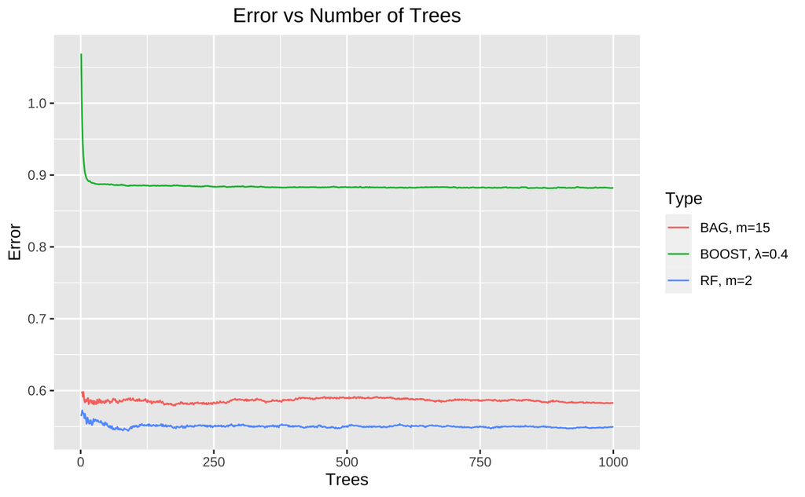

```r
model2.err <- data.frame(
  Trees=1:1000,
  Error=c(bag.model2e$err.rate[,"OOB"],bag.model2a$err.rate[,"OOB"],
          model2.boost5$train.error),
  Type=rep(c("RF, m=2","BAG, m=15","BOOST, λ=0.4"), each=1000)
)
ggplot(data=model2.err, aes(x=Trees, y=Error)) +  geom_line(aes(color=Type)) + ggtitle("Error vs Number of Trees") +xlim(0,1000)+theme(plot.title = element_text(hjust=0.5))
```

##### Model 3 Regression

Response Variable : IRMJFY - MARIJUANA FREQUENCY PAST YEAR(2019) - IMPUTATION REVISED

###### Feature Selection

```r
info_gain_3 <- information.gain(irmjfy ~ ., data=df)
info_gain_3
```

|  | attr_importance |
| --- | --- |
| ymdelt | 1.082756e-02 |
| CATAG7 | 2.499269e-02 |
| drvindrg | 3.288745e-02 |
| uadfwho | 2.990578e-02 |
| irwrkstat | 2.551483e-02 |
| rskmrjwk | 4.338676e-02 |
| iralcfy | 7.324172e-02 |
| irmjfm | 1.156257e-01 |
| irmjage | 1.742420e-01 |
| mrjflag | 1.740097e-01 |

[output cut: 69 more lines]

Subsetting the dataset with the inportant variables

```r
df3 <- df %>% select(c('irmjfy','tobflag','uadfwho','prmjmo','HEALTH2','YFLTMRJ2','eduschlgo','cigmdays','stndsmj','EDUSCHGRD2','ANYEDUC3','COUTYP4','CATAG7'))
```

###### Splitting up the dataset for the model 3

```r
set.seed(5)
train <- sample(1:nrow(df3), nrow(df)*0.7)
NSDUH_train_set_3 <- df3[train,]
NSDUH_test_set_3 <- df3[-train,]
```

###### Decision Tree

```r
model_3 <- tree(irmjfy~ tobflag+uadfwho+prmjmo+HEALTH2+YFLTMRJ2+eduschlgo+
                  cigmdays+stndsmj+EDUSCHGRD2+ANYEDUC3+COUTYP4+CATAG7,NSDUH_train_set_3)
summary(model_3)
```

```
Regression tree:
tree(formula = irmjfy ~ tobflag + uadfwho + prmjmo + HEALTH2 +
    YFLTMRJ2 + eduschlgo + cigmdays + stndsmj + EDUSCHGRD2 +
    ANYEDUC3 + COUTYP4 + CATAG7, data = NSDUH_train_set_3)
Variables actually used in tree construction:
[1] "tobflag"   "uadfwho"   "prmjmo"    "cigmdays"  "HEALTH2"   "stndsmj"   "eduschlgo"
Number of terminal nodes:  10
Residual mean deviance:  1263 = 4847000 / 3839
Distribution of residuals:
     Min.   1st Qu.    Median      Mean   3rd Qu.      Max.
-217.6000   -0.6891   -0.6891    0.0000   -0.6891  346.1000
```

```r
test.pred_3 <- predict(model_3,NSDUH_test_set_3)
mean((test.pred_3-NSDUH_test_set_3$irmjfy)^2)
```

```
[1] 1430.548
```

The residual mean of training data is 1263 The residual mean of test data is 1430

###### Cross-Validation to select the optimum tree size

```r
# Using cross validation
set.seed(0)
cv.model3 <- cv.tree(model_3)
cv.model3
```

```
$size
 [1] 10  9  8  7  6  5  4  3  2  1

$dev
 [1] 5836452 5902261 5862890 5921487 5925707 5918570 5918570 6432630 7123933 8007098

$k
 [1]       -Inf   82764.08   85628.92  136436.25  153048.74  155824.69  166527.97  366247.48  653387.21 1349156.36

$method
[1] "deviance"

attr(,"class")
[1] "prune"         "tree.sequence"
```

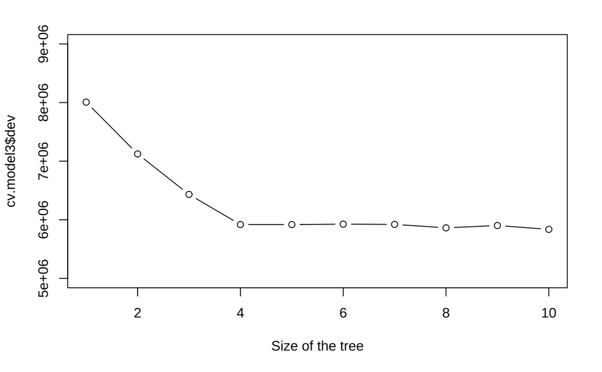

```r
plot(cv.model3$size,cv.model3$dev,type="b",xlab = "Size of the tree","",xlim=c(1,10),ylim = c(5000000,9000000))
```

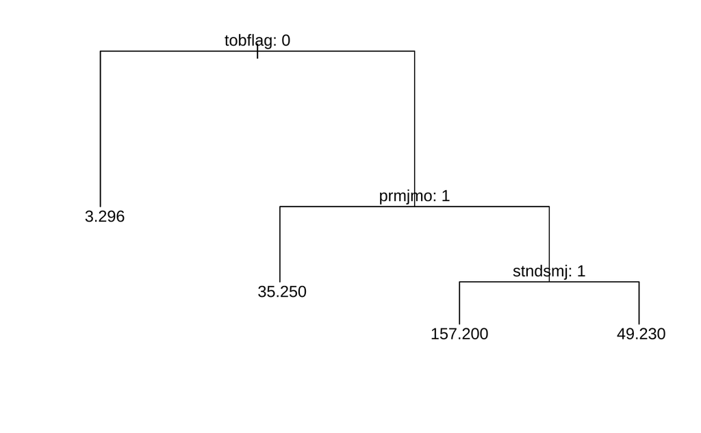

```r
# Pruning the tree

prune.model3 <- prune.tree(model_3,best=4)
plot(prune.model3)
text(prune.model3,pretty=0)
```

```r
NA
NA
```

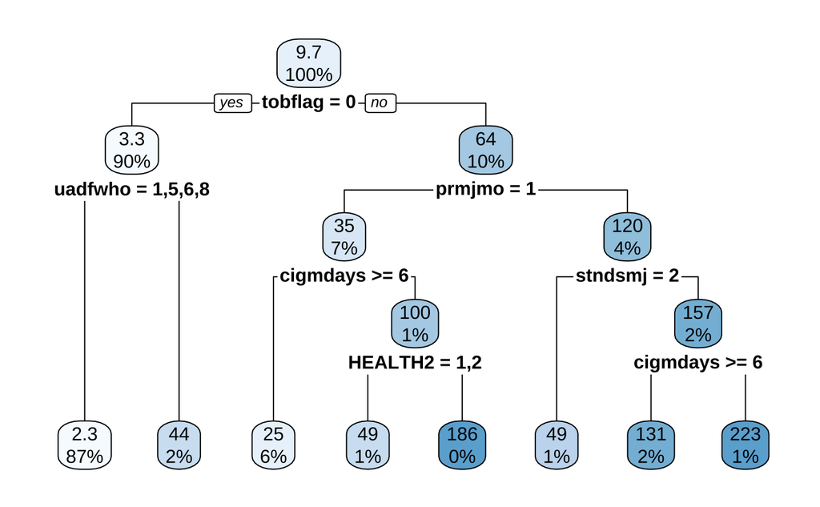

```r
df_rpart_3_pruned <- rpart(model_3, data = NSDUH_train_set_3)
rpart.plot(prune(df_rpart_3_pruned,cp=0.015))
```

```r
NA
NA
```

```r
# Predicting the  training and test set with the pruned tree model
prune.pred_3 <- predict(prune.model3,NSDUH_train_set_3)
print(paste("Training set Mse of the pruned tree model:",round(mean((prune.pred_3 - NSDUH_train_set_3$irmjfy)^2))))
```

```
[1] "Training set Mse of the pruned tree model: 1462"
```

```r
prune.pred_3 <- predict(prune.model3,NSDUH_test_set_3)
print(paste("Test set Mse of the pruned tree model:",round(mean((prune.pred_3 - NSDUH_test_set_3$irmjfy)^2))))
```

```
[1] "Test set Mse of the pruned tree model: 1433"
```

The test MSE of the pruned tree has not improved

###### Bagging and Random Forest:

```r
set.seed(5)

p <- seq(1,13,by=1)
error<-c( )

for(i in 1:length(p))
{
  rf.model3 <- randomForest(irmjfy ~ ., data = NSDUH_train_set_3, mtry = i, importance = TRUE)
yhat.rf <- predict(rf.model3,NSDUH_test_set_3)
error[i] = mean((yhat.rf - NSDUH_test_set_3$irmjfy)^2)

}
```

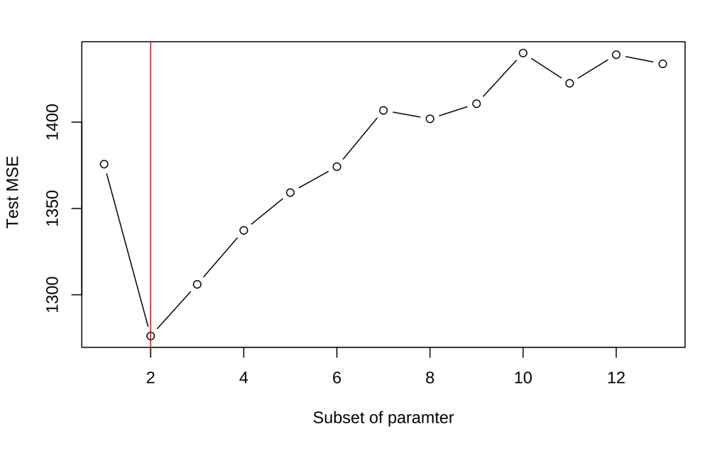

```r
plot(p,error,type="b",xlab ="Subset of paramter",ylab=" Test MSE")
index<- which.min(error) # Index of the minimum MSE
Min_error <- error[index]
min_p <- p[index]
abline(v=min_p,col="red")
```

```r
#text(min_p,Min_error,"Least Mse")
best_subset = min_p

print(paste("Best number of subset of variable selection is : ",best_subset))
```

```
[1] "Best number of subset of variable selection is :  2"
```

```r
rf.model3s <- randomForest(irmjfy ~ ., data = NSDUH_test_set_3, mtry = 13,ntree=500,importance = TRUE)
```

```r
importance(rf.model3s)
```

```
               %IncMSE IncNodePurity
tobflag    -10.2918072     424487.39
uadfwho     -1.6615369     398029.20
prmjmo     -11.2510696     281674.78
HEALTH2     -0.8491218     268889.24
YFLTMRJ2    -7.7069597     184094.09
eduschlgo   -0.8636796      81165.33
cigmdays     1.2716731     147483.22
stndsmj     -4.4681251     187993.02
EDUSCHGRD2  -1.8006069     295843.90
ANYEDUC3     1.3338323      95195.02
COUTYP4     -2.6307612     227913.34
CATAG7      -5.6044519      77794.18
```

```r
rf.model3a <- randomForest(irmjfy ~ ., data = NSDUH_test_set_3, mtry = 2,ntree=1000,importance = TRUE)
rf.model3b <- randomForest(irmjfy ~ ., data = NSDUH_test_set_3, mtry = 7,ntree=1000, importance = TRUE)
rf.model3c <- randomForest(irmjfy ~ ., data = NSDUH_test_set_3, mtry = 9,ntree=1000,importance = TRUE)
rf.model3s <- randomForest(irmjfy ~ ., data = NSDUH_test_set_3, mtry = 13,ntree=1000,importance = TRUE)
```

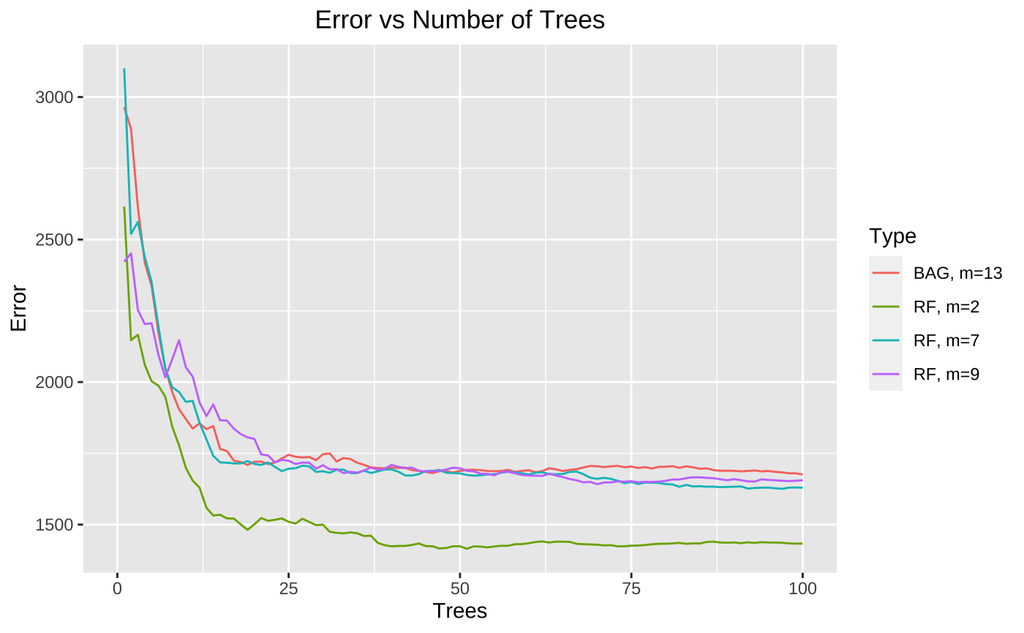

```r
# Graph to plot the error rate for different parameters for m = p,p/2,srt(p)

model3.err <- data.frame(
  Trees=1:500,
  Error=c(rf.model3a$mse,rf.model3b$mse, rf.model3c$mse,rf.model3s$mse),
  Type=rep(c("RF, m=2","RF, m=7", "RF, m=9","BAG, m=13"), each=500)
)
ggplot(data=model3.err, aes(x=Trees, y=Error)) +  geom_line(aes(color=Type)) + ggtitle("Error vs Number of Trees") +xlim(0,100)+theme(plot.title = element_text(hjust=0.5))
```

Training and Test performance rate:

```r
rf.model3c <- randomForest(irmjfy ~ ., data = NSDUH_train_set_3, mtry = 2,ntree=500,importance = TRUE)
yhat.rf <- predict(rf.model3c,NSDUH_train_set_3)
mean((yhat.rf - NSDUH_train_set_3$irmjfy)^2)
```

```
[1] 813.5711
```

```r
rf.model3s <- randomForest(irmjfy ~ ., data = NSDUH_train_set_3, mtry = 13,ntree=500,importance = TRUE)
yhat.rf <- predict(rf.model3s,NSDUH_train_set_3)
mean((yhat.rf - NSDUH_train_set_3$irmjfy)^2)
```

```
[1] 469.938
```

```r
rf.model3c <- randomForest(irmjfy ~ ., data = NSDUH_train_set_3, mtry = 2,ntree=500,importance = TRUE)
yhat.rf <- predict(rf.model3c,NSDUH_test_set_3)
mean((yhat.rf - NSDUH_test_set_3$irmjfy)^2)
```

```
[1] 1279.031
```

```r
rf.model3s <- randomForest(irmjfy ~ ., data = NSDUH_train_set_3, mtry = 13,ntree=500,importance = TRUE)
yhat.rf <- predict(rf.model3s,NSDUH_test_set_3)
mean((yhat.rf - NSDUH_test_set_3$irmjfy)^2)
```

```
[1] 1442.482
```

###### Boosting:

```r
set.seed(1)
power <- seq(-3,0,0.01)
lambda <- 10^power
error <- rep(NA, length(lambda))

for (i in 1:length(lambda))
{
  boost.model3 <- gbm(irmjfy ~. , data = NSDUH_train_set_3,
      distribution = "gaussian", n.trees = 1000,shrinkage =lambda[i])

  boost.pred3 <- predict(boost.model3,NSDUH_test_set_3,n.trees = 1000)

  error[i] <- mean((boost.pred3 - NSDUH_test_set_3$irmjfy)^2 )
}
```

[figure not shown]

```r
index <- which.min(error)
min_error <- error[index]
min_lambda <- lambda[index]
plot(lambda,error,xlab = "Shrinkage parameter(λ)", ylab = "MSE of the training data",xlim=c(0,1),type="b")
title("Boosting model shrinkage parameter by training error")
```

```r
print(paste("best shrinkage vale:",min_lambda,"with MSE of ",min_error))
```

```
[1] "best shrinkage vale: 0.0093325430079699 with MSE of  1437.9156424748"
```

```r
min_error
```

```
[1] 1437.916
```

```r
boost.model3a <- gbm(irmjfy ~. , data = NSDUH_test_set_3,distribution = "gaussian", n.trees = 1000,shrinkage =0.01)
boost.model3b <- gbm(irmjfy ~. , data = NSDUH_test_set_3,distribution = "gaussian", n.trees = 1000,shrinkage =0.02)
boost.model3c <- gbm(irmjfy ~. , data = NSDUH_test_set_3,distribution = "gaussian", n.trees = 1000,shrinkage =0.05)
boost.model3d <- gbm(irmjfy ~. , data = NSDUH_test_set_3,distribution = "gaussian", n.trees = 1000,shrinkage =0.1)
```

###### Comapring the shrinkage parametes:

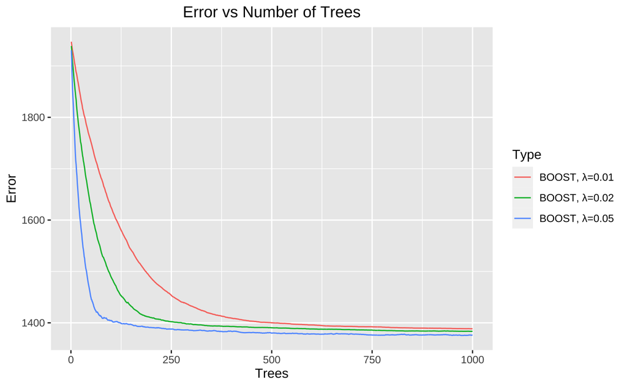

```r
model3.err <- data.frame(
  Trees=1:1000,
  Error=c(boost.model3a$train.error,boost.model3b$train.error, boost.model3c$train.error),
  Type=rep(c("BOOST, λ=0.01","BOOST, λ=0.02", "BOOST, λ=0.05"), each=1000)
)
ggplot(data=model3.err, aes(x=Trees, y=Error)) +  geom_line(aes(color=Type)) + ggtitle("Error vs Number of Trees") +xlim(0,1000)+theme(plot.title = element_text(hjust=0.5))
```